# Documentação - Painéis Interativos (UTFPR)

João Pedro Gava Ribeiro

Rodrigo Belniok Czelusniak

v.1 (30/01/2024)

**EM ELABORAÇÃO!**

# 1 Tipos de Visuais

## 1.1 Nativos

### 1.1.1 Waffle Chart

Usa do visual nativo **matriz**

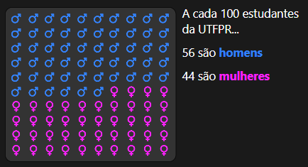

Waffle Chart como **infográfico**

### 1.1.2 Mapa de Formas

Usa do visual nativo **mapa de formas**

Depende de **ativação** dessa opção

Em Arquivo > Opções e configurações > Opções > Recursos de visualização > Moldar visual do mapa

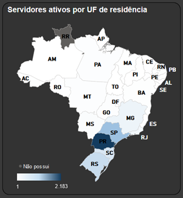

Mapa de Formas das UFs brasileiras

### 1.1.3 Treemap

Usa do visual nativo **treemap**

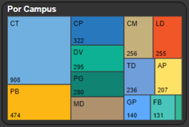

Treemap dos campi da UTFPR

## 1.2 Personalizados

### 1.2.1 Sunburst

Usa o visual personalizado **sunburst**

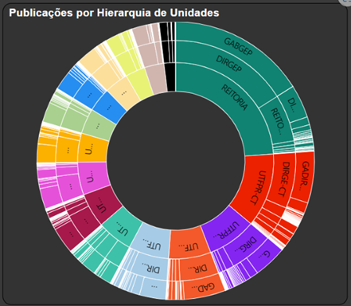

Sunburst das unidades do SEI

### 1.2.2 Sankey Chart

Usa o visual personalizado **sankey chart**

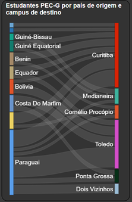

Sankey Chart para fluxo de estudantes PEC-G

# 2 Padrões de Formatação

# 3 Padrões de Ícones

## 3.1 Campi

Img/Link

Campus

HEX

Exemplo

HEX Dalt.

Exemplo Dalt.

Apucarana

#FCDF9B

⬤

#F5F534

▦

Campo Mourão

#FCB000

⬤

#F5F534

▨

Cornélio Procópio

#F3592A

⬤

#F5F534

▩

Curitiba

#EB2100

⬤

#B5B5D4

▦

Dois Vizinhos

#A6CBE6

⬤

#B5B5D4

▨

Francisco Beltrão

#268EF0

⬤

#B5B5D4

▩

Guarapuava

#D0B5AF

⬤

#7979FB

▦

Londrina

#A9D08E

⬤

#7979FB

▨

Medianeira

#3EC1A9

⬤

#7979FB

▩

Pato Branco

#8525F1

⬤

#FFFFFF

▦

Ponta Grossa

#A7194B

⬤

#FFFFFF

▨

Reitoria

#108372

⬤

#FFFFFF

▩

Santa Helena

#E8F275

⬤

#B2B22E

▦

Toledo

#E651DA

⬤

#B2B22E

▨

## 3.2 Ensino

### 3.2.1 Geral

| Img/Link | Semântica | Tipo | Nome/Fonte | HEX |
| --- | --- | --- | --- | --- |
|  | Ativos/Regulares | Font Awesome LaTeX | [faBook](https://linorg.usp.br/CTAN/fonts/fontawesome/doc/fontawesome.pdf) | #0EB194 |
|  | Formados | Font Awesome | [fa-user-graduate](https://fontawesome.com/icons/user-graduate?f=classic&s=solid) | #1D4999 |
|  | Desistentes/Evadidos | Font Awesome | [fa-person-running](https://fontawesome.com/icons/person-running?f=classic&s=solid) + [fa-door-open](https://fontawesome.com/icons/door-open?f=classic&s=solid) | #BE5108 |
|  | Estudantes | Font Awesome | [fa-users](https://fontawesome.com/icons/users?f=classic&s=solid) | #FF8800 |
|  | Cursos | Font Awesome | [fa-pencil](https://fontawesome.com/icons/pencil?f=classic&s=solid) | #3DAD00 |
|  | Candidatos | Font Awesome | [fa-hand-point-up](https://fontawesome.com/icons/hand-point-up?f=classic&s=solid) | #00E1FF |
|  | Vagas | Font Awesome | [fa-chair](https://fontawesome.com/icons/chair?f=classic&s=solid) | #FFAE00 |

### 3.2.2 Áreas SESU

Tais ícones foram usados no visual personalizado Facet Key (**descontinuado**) da parte de Cursos e Programas. Caso use o visual, o próprio Power BI os gera a partir do nome do ícone.

| Img/Link | Semântica | Tipo | Nome/Fonte | HEX |
| --- | --- | --- | --- | --- |
|  | ENG/Engenharias | Font Awesome Facet Key | [fa fa-gear](https://fontawesome.com/icons/gear?f=classic&s=solid) | #FF001F |
|  | CA/Ciências Agrárias | Font Awesome Facet Key | [fa fa-leaf](https://fontawesome.com/icons/leaf?f=classic&s=solid) | #108372 |
|  | A/Artes | Font Awesome Facet Key | [fa fa-paint-brush](https://fontawesome.com/icons/paint-brush?f=classic&s=solid) | #0EB194 |
|  | LL/Linguística e Letras | Font Awesome Facet Key | [fa fa-pencil](https://fontawesome.com/icons/pencil?f=classic&s=solid) | #FCB714 |
|  | CE2/Ciências Exatas - Computação | Font Awesome Facet Key | [fa fa-laptop](https://fontawesome.com/icons/laptop?f=classic&s=solid) | #DB00B0 |
|  | TEC/Tecnólogos | Font Awesome Facet Key | [fa fa-wrench](https://fontawesome.com/icons/wrench?f=classic&s=solid) | #FF8000 |
|  | CE1/Ciências Exatas - Matemática e Estatística | Font Awesome Facet Key | [fa fa fa-calculator](https://fontawesome.com/icons/calculator?f=classic&s=solid) | #95AF00 |
|  | CSA/Ciências Sociais Aplicadas | Font Awesome Facet Key | [fa fa-briefcase](https://fontawesome.com/icons/briefcase?f=classic&s=solid) | #70B0E0 |
|  | CSC/Arquitetura/Urbanismo | Font Awesome Facet Key | [fa fa-building](https://fontawesome.com/icons/building?f=classic&s=solid) | #2878BD |
|  | CS4/Enfermagem, Fisioterapia, Fonaudiologia | Font Awesome Facet Key | [fa fa-stethoscope](https://fontawesome.com/icons/stethoscope?f=classic&s=solid) | #C4B07B |
|  | CS2/Veterinária, Odontologia, Zootecnia | Font Awesome Facet Key | [fa fa-paw](https://fontawesome.com/icons/paw?f=classic&s=solid) | #F15628 |
|  | CB/Ciências Biológicas | Font Awesome Facet Key | [fa fa-flask](https://fontawesome.com/icons/flask?f=classic&s=solid) | #AF916D |
|  | CET/Ciências Exatas e da Terra | Font Awesome Facet Key | [fa fa-line-chart](https://fontawesome.com/icons/line-chart?f=classic&s=solid) | #1BBB6A |
|  | ME/Mestrado | Font Awesome Facet Key | [fa fa-book](https://linorg.usp.br/CTAN/fonts/fontawesome/doc/fontawesome.pdf) | #AC8000 |
|  | DR/Doutorado | Font Awesome Facet Key | [fa fa-book](https://linorg.usp.br/CTAN/fonts/fontawesome/doc/fontawesome.pdf) | #B44AE7 |

## 3.3 Assistência Estudantil

| Img/Link | Semântica | Tipo | Nome/Fonte | HEX |
| --- | --- | --- | --- | --- |
|  | Auxílio Alimentação | Font Awesome | [fa-utensils](https://fontawesome.com/icons/utensils?f=classic&s=solid) | #FFA400 |
|  | Auxílio Básico | Font Awesome | [fa-hand-holding-dollar](https://fontawesome.com/icons/hand-holding-dollar?f=classic&s=solid) | #FFEE00 |
|  | Auxílio Moradia | Font Awesome | [fa-house](https://fontawesome.com/icons/house?f=classic&s=duotone) | #A1BBD4/ #145692 |
|  | Auxílio Emergencial | Font Awesome | [fa-truck-medical](https://fontawesome.com/icons/truck-medical?f=classic&s=solid) | #FF0000 |
|  | Auxílio de Inclusão Digital | Font Awesome | [fa-mobile-screen-button](https://fontawesome.com/icons/mobile-screen-button?f=classic&s=solid) | #5862FF |

## 3.4 Relatório de Gestão

Img/Link

Semântica

Tipo

Nome/Fonte

HEX

Ensino Fundamental

Font Awesome

[fa-chalkboard](https://fontawesome.com/icons/chalkboard?f=classic&s=solid)  
+ [fa-apple-whole](https://fontawesome.com/icons/apple-whole?f=classic&s=solid)

#7F3300/#16663F/  
#CC5100/#FF0000/#00DB00

Ensino Médio

Font Awesome

[fa-chalkboard](https://fontawesome.com/icons/chalkboard?f=classic&s=solid)  
+ [fa-function](https://fontawesome.com/icons/function?f=classic&s=solid)

#7F3300/#16663F/  
#CC5100/#000000

Técnico

Font Awesome

[fa-hammer](https://fontawesome.com/icons/hammer?f=classic&s=solid)

#8B8B8B/#5A3000

Graduação/Graduado

Font Awesome

[faGraduationCap](https://linorg.usp.br/CTAN/fonts/fontawesome/doc/fontawesome.pdf)

#2878BD

Especialização/Especialista

Font Awesome

[fa-radar](https://fontawesome.com/icons/radar?f=classic&s=regular)

#218000

Mestrado/Mestre/Dissertação

Font Awesome

[fa-book](https://fontawesome.com/icons/book?f=classic&s=solid)

#B31F1B

Doutorado/Doutor/Tese

Font Awesome

[fa-book-bookmark](https://fontawesome.com/icons/book-bookmark?f=classic&s=solid)

#C17E55/#441B00/  
#FF0000/#D8D8D8